Fecha: 28 Octubre 2019

NOTA: Ten cuidado en ejecutar sobre los resultados guía esperados!

# Proyecto de regresión logística

En este proyecto, trabajaremos con un conjunto de datos publicitarios falsos, que indica si un usuario de Internet en particular hizo clic o no en un anuncio en el sitio web de una empresa. Intentaremos crear un modelo que prediga si harán clic o no en un anuncio en función de las características de ese usuario.

Este conjunto de datos contiene las siguientes características:

- 'Daily Time Spent on Site': tiempo del consumidor en el sitio en minutos
- 'Age': edad del cliente en años
- 'Area Income': Prom. Ingresos del área geográfica del consumidor
- 'Daily Internet Usage': Prom. minutos al día el consumidor está en internet
- 'Ad Topic Line': título del anuncio
- 'City': Ciudad del consumidor
- 'Male': si el consumidor era o no hombre
- 'Country': País del consumidor
- 'Timestamp': hora en que el consumidor hizo clic en el anuncio o en la ventana cerrada
- 'Clicked on Ad': 0 o 1 indicaron hacer clic en el anuncio

## Importar librerías

**Importa algunas librerías que crees que necesitarás (¡O simplemente impórtalas a medida que avanzas!)**

```python
import pandas as pd
from sklearn.linear_model import LogisticRegression
from sklearn.model_selection import train_test_split
import matplotlib.mlab as mlab
import matplotlib.pyplot as plt
import seaborn as sns
```

## Obtener los datos

**Leer el archivo advertising.csv y configúrarlo en un Dataframe llamado ad_data.**

```python
url = 'advertising.csv'
ad_data = pd.read_csv(url)
```

```python
ad_data.head()
```

|  | Daily Time Spent on Site | Age | Area Income | Daily Internet Usage | Ad Topic Line | City | Male | Country | Timestamp | Clicked on Ad |
| --- | --- | --- | --- | --- | --- | --- | --- | --- | --- | --- |
| 0 | 68.95 | 35 | 61833.90 | 256.09 | Cloned 5thgeneration orchestration | Wrightburgh | 0 | Tunisia | 2016-03-27 00:53:11 | 0 |
| 1 | 80.23 | 31 | 68441.85 | 193.77 | Monitored national standardization | West Jodi | 1 | Nauru | 2016-04-04 01:39:02 | 0 |
| 2 | 69.47 | 26 | 59785.94 | 236.50 | Organic bottom-line service-desk | Davidton | 0 | San Marino | 2016-03-13 20:35:42 | 0 |
| 3 | 74.15 | 29 | 54806.18 | 245.89 | Triple-buffered reciprocal time-frame | West Terrifurt | 1 | Italy | 2016-01-10 02:31:19 | 0 |
| 4 | 68.37 | 35 | 73889.99 | 225.58 | Robust logistical utilization | South Manuel | 0 | Iceland | 2016-06-03 03:36:18 | 0 |

**Usa info y describe() en ad_data**

```python
ad_data.info()
```

```
<class 'pandas.core.frame.DataFrame'>
RangeIndex: 1000 entries, 0 to 999
Data columns (total 10 columns):
Daily Time Spent on Site    1000 non-null float64
Age                         1000 non-null int64
Area Income                 1000 non-null float64
Daily Internet Usage        1000 non-null float64
Ad Topic Line               1000 non-null object
City                        1000 non-null object
Male                        1000 non-null int64
Country                     1000 non-null object
Timestamp                   1000 non-null object
Clicked on Ad               1000 non-null int64
dtypes: float64(3), int64(3), object(4)
memory usage: 78.2+ KB
```

```python
ad_data.describe()
```

|  | Daily Time Spent on Site | Age | Area Income | Daily Internet Usage | Male | Clicked on Ad |
| --- | --- | --- | --- | --- | --- | --- |
| count | 1000.000000 | 1000.000000 | 1000.000000 | 1000.000000 | 1000.000000 | 1000.00000 |
| mean | 65.000200 | 36.009000 | 55000.000080 | 180.000100 | 0.481000 | 0.50000 |
| std | 15.853615 | 8.785562 | 13414.634022 | 43.902339 | 0.499889 | 0.50025 |
| min | 32.600000 | 19.000000 | 13996.500000 | 104.780000 | 0.000000 | 0.00000 |
| 25% | 51.360000 | 29.000000 | 47031.802500 | 138.830000 | 0.000000 | 0.00000 |
| 50% | 68.215000 | 35.000000 | 57012.300000 | 183.130000 | 0.000000 | 0.50000 |
| 75% | 78.547500 | 42.000000 | 65470.635000 | 218.792500 | 1.000000 | 1.00000 |
| max | 91.430000 | 61.000000 | 79484.800000 | 269.960000 | 1.000000 | 1.00000 |

## Análisis exploratorio de datos

¡Usemos Seaborn para explorar los datos!

¡Intenta recrear las tramas que se muestran a continuación!

**Crea un histograma de age**

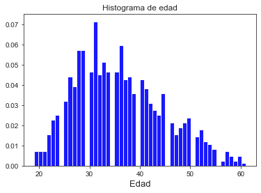

```python
x1 = ad_data['Age']
x1, x2, patches = plt.hist(x1, 50, density=True, facecolor='b', alpha=0.90)
plt.title('Histograma de edad')
plt.xlabel('Edad',fontsize = 13 )
```

**Crea a jointplot mostrando Area Income vs Age.**

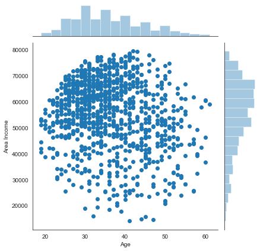

```python
with sns.axes_style('white'):
    sns.jointplot("Age", "Area Income", ad_data, kind='scatter')
```

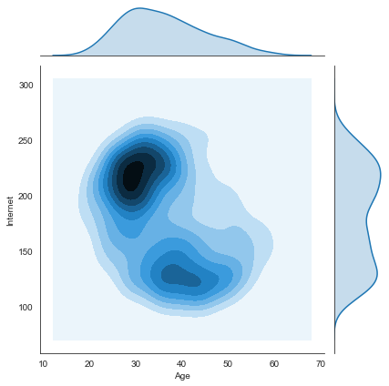

```python
ad_data.rename(columns=lambda x: x.replace('Daily Internet Usage', 'Internet'), inplace=True)
with sns.axes_style('white'):
    sns.jointplot("Age", "Internet", ad_data, kind='kde')
```

**Crear un jointplot de 'Daily Time Spent on Site' vs. 'Daily Internet Usage'**

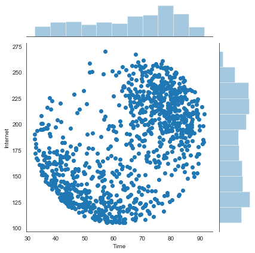

```python
ad_data.rename(columns=lambda x: x.replace('Daily Time Spent on Site', 'Time'), inplace=True)
with sns.axes_style('white'):
    sns.jointplot("Time", "Internet", ad_data, kind='scatter')
```

**Finalmente, crear un pairplot con el hue definido con la columna caracteristica 'Clicked on Ad'.**

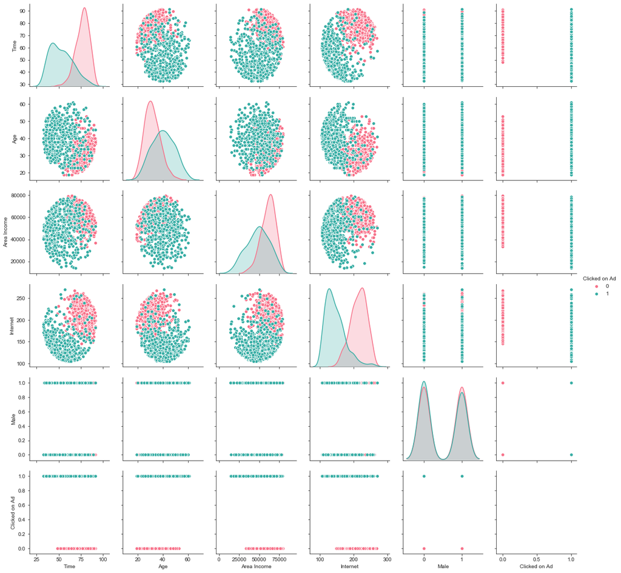

```python
sns.set_style("ticks")
sns.pairplot(ad_data,hue = 'Clicked on Ad',diag_kind = "kde",kind = "scatter",palette = "husl")
plt.show()
```

# Regresión logística

¡Ahora es el momento de hacer una separación de los datos para el entrenamiento y para la prueba. Luego entrenar a nuestro modelo!

¡Tendrás la libertad de elegir las columnas que quieras entrenar!

**Dividir los datos en un conjunto de entrenamiento y un conjunto de pruebas usando train_test_split ****

```python
ad_data.rename(columns=lambda x: x.replace('Area Income', 'Income'), inplace=True)
X = ad_data.Income
y = ad_data.Internet
```

```python
from sklearn.model_selection import train_test_split
```

```python
X_train, X_test, y_train, y_test = train_test_split(X, y, test_size=0.2)
```

**Entrenar y ajustar un modelo de regresión logística en el conjunto de entrenamiento.**

```python
from sklearn.preprocessing import StandardScaler
model = linear_model.LogisticRegression()
model.fit(X,y)
escalar = StandardScaler()
X_train = escalar.fit_transform(X_train)
X_test = escalar.transform(X_test)
from sklearn.linear_model import LogisticRegression
algoritmo = LogisticRegression()
algoritmo.fit(X_train, y_train)
y_pred = algoritmo.predict(X_test)
model.fit(X,y)
```

[output not shown]

[output cut: 102 more lines]

[output not shown]

## Predicciones y evaluaciones

**Ahora predice valores para los datos de prueba.**

```python
y_pred = algoritmo.predict(X_test)
```

[output not shown]

[output not shown]